# Statistical Learning

Natalia Misiaszek

2026-04-07

```r
data= read.csv("/Users/misiaszekn/Downloads/WA_Fn-UseC_-Telco-Customer-Churn.csv")
```

# Dane

Zbiór zawiera dane klientów pewnej firmy telekomunikacyjnej, takie jak:

1. osobiste dane klienta:
   - customer ID,
   - gender,
   - SeniorCitizen - czy klient jest seniorem,
   - Partner - czy ma partnera czy też nie,
   - Dependents - czy ma osoby na utrzymaniu,
2. relacja z firmą telekomunikacyjną:
   - tenure - ile miesięcy klient pozostał z firmą,
3. usługi telefoniczne:
   - PhoneService - czy firma świadczy klientowi usługę telefoniczną,
   - MultipleLines - czy klient ma wiecej niż jedną linię telefoniczną,
4. internet i usługi dodatkowe:
   - InternetService - firma dostarczająca internet klientowi,
   - OnlineSecurity,
   - OnlineBackup,
   - Device Protection,
   - TechSupport,
   - StreamingTV,
   - StreamingMovies,
5. umowa i płatności:
   - Contract,
   - PaperlessBilling - czy rachunki są elektroniczne,
   - PaymentMethod,
6. opłaty:
   - MonthlyCharges,
   - TotalCharges,
7. zmienna docelowa - **Churn** - czy klient odszedł czy też nie.

Nasz zbiór danych zawiera łącznie $7043$ obserwacji.

## Kontekst projektu

Naszym zadaniem będzie przewidzenie, czy dany klient o pewnych “parametrach” odejdzie od firmy telekomunikacyjnej, czy też nie, oraz w pierwszym przypadku dokładne skupienie się na dostosowaniu usług jeszcze dokładniej do klienta oraz potencjalne zaoferowanie mu korzystniejszych warunków umowy, tak aby go nie stracić.

## Braki i duplikaty

```r
colSums(is.na(data))
```

```
##       customerID           gender    SeniorCitizen          Partner
##                0                0                0                0
##       Dependents           tenure     PhoneService    MultipleLines
##                0                0                0                0
##  InternetService   OnlineSecurity     OnlineBackup DeviceProtection
##                0                0                0                0
##      TechSupport      StreamingTV  StreamingMovies         Contract
##                0                0                0                0
## PaperlessBilling    PaymentMethod   MonthlyCharges     TotalCharges
##                0                0                0               11
##            Churn
##                0
```

Mamy jedynie $11$ braków wśród $7043$ obserwacji, tak że możemy je śmiało pominąć.

```r
sum(duplicated(data))
```

```
## [1] 0
```

```r
data_cl= na.omit(data)
```

## Zamiana zmiennych char na factor

```r
data_cl[]= lapply(data_cl, function(x){
  if (is.character(x)) as.factor(x) else x
})
```

```r
str(data_cl)
```

```
## 'data.frame':    7032 obs. of  21 variables:
##  $ customerID      : Factor w/ 7032 levels "0002-ORFBO","0003-MKNFE",..: 5366 3954 2559 5525 6501 6541 1002 4761 5594 4525 ...
##  $ gender          : Factor w/ 2 levels "Female","Male": 1 2 2 2 1 1 2 1 1 2 ...
##  $ SeniorCitizen   : int  0 0 0 0 0 0 0 0 0 0 ...
##  $ Partner         : Factor w/ 2 levels "No","Yes": 2 1 1 1 1 1 1 1 2 1 ...
##  $ Dependents      : Factor w/ 2 levels "No","Yes": 1 1 1 1 1 1 2 1 1 2 ...
##  $ tenure          : int  1 34 2 45 2 8 22 10 28 62 ...
##  $ PhoneService    : Factor w/ 2 levels "No","Yes": 1 2 2 1 2 2 2 1 2 2 ...
##  $ MultipleLines   : Factor w/ 3 levels "No","No phone service",..: 2 1 1 2 1 3 3 2 3 1 ...
##  $ InternetService : Factor w/ 3 levels "DSL","Fiber optic",..: 1 1 1 1 2 2 2 1 2 1 ...
##  $ OnlineSecurity  : Factor w/ 3 levels "No","No internet service",..: 1 3 3 3 1 1 1 3 1 3 ...
##  $ OnlineBackup    : Factor w/ 3 levels "No","No internet service",..: 3 1 3 1 1 1 3 1 1 3 ...
##  $ DeviceProtection: Factor w/ 3 levels "No","No internet service",..: 1 3 1 3 1 3 1 1 3 1 ...
##  $ TechSupport     : Factor w/ 3 levels "No","No internet service",..: 1 1 1 3 1 1 1 1 3 1 ...
##  $ StreamingTV     : Factor w/ 3 levels "No","No internet service",..: 1 1 1 1 1 3 3 1 3 1 ...
##  $ StreamingMovies : Factor w/ 3 levels "No","No internet service",..: 1 1 1 1 1 3 1 1 3 1 ...
##  $ Contract        : Factor w/ 3 levels "Month-to-month",..: 1 2 1 2 1 1 1 1 1 2 ...
##  $ PaperlessBilling: Factor w/ 2 levels "No","Yes": 2 1 2 1 2 2 2 1 2 1 ...
##  $ PaymentMethod   : Factor w/ 4 levels "Bank transfer (automatic)",..: 3 4 4 1 3 3 2 4 3 1 ...
##  $ MonthlyCharges  : num  29.9 57 53.9 42.3 70.7 ...
##  $ TotalCharges    : num  29.9 1889.5 108.2 1840.8 151.7 ...
##  $ Churn           : Factor w/ 2 levels "No","Yes": 1 1 2 1 2 2 1 1 2 1 ...
##  - attr(*, "na.action")= 'omit' Named int [1:11] 489 754 937 1083 1341 3332 3827 4381 5219 6671 ...
##   ..- attr(*, "names")= chr [1:11] "489" "754" "937" "1083" ...
```

# Analiza danych

```r
dim(data_cl)
```

```
## [1] 7032   21
```

```r
str(data_cl)
```

```
## 'data.frame':    7032 obs. of  21 variables:
##  $ customerID      : Factor w/ 7032 levels "0002-ORFBO","0003-MKNFE",..: 5366 3954 2559 5525 6501 6541 1002 4761 5594 4525 ...
##  $ gender          : Factor w/ 2 levels "Female","Male": 1 2 2 2 1 1 2 1 1 2 ...
##  $ SeniorCitizen   : int  0 0 0 0 0 0 0 0 0 0 ...
##  $ Partner         : Factor w/ 2 levels "No","Yes": 2 1 1 1 1 1 1 1 2 1 ...
##  $ Dependents      : Factor w/ 2 levels "No","Yes": 1 1 1 1 1 1 2 1 1 2 ...
##  $ tenure          : int  1 34 2 45 2 8 22 10 28 62 ...
##  $ PhoneService    : Factor w/ 2 levels "No","Yes": 1 2 2 1 2 2 2 1 2 2 ...
##  $ MultipleLines   : Factor w/ 3 levels "No","No phone service",..: 2 1 1 2 1 3 3 2 3 1 ...
##  $ InternetService : Factor w/ 3 levels "DSL","Fiber optic",..: 1 1 1 1 2 2 2 1 2 1 ...
##  $ OnlineSecurity  : Factor w/ 3 levels "No","No internet service",..: 1 3 3 3 1 1 1 3 1 3 ...
##  $ OnlineBackup    : Factor w/ 3 levels "No","No internet service",..: 3 1 3 1 1 1 3 1 1 3 ...
##  $ DeviceProtection: Factor w/ 3 levels "No","No internet service",..: 1 3 1 3 1 3 1 1 3 1 ...
##  $ TechSupport     : Factor w/ 3 levels "No","No internet service",..: 1 1 1 3 1 1 1 1 3 1 ...
##  $ StreamingTV     : Factor w/ 3 levels "No","No internet service",..: 1 1 1 1 1 3 3 1 3 1 ...
##  $ StreamingMovies : Factor w/ 3 levels "No","No internet service",..: 1 1 1 1 1 3 1 1 3 1 ...
##  $ Contract        : Factor w/ 3 levels "Month-to-month",..: 1 2 1 2 1 1 1 1 1 2 ...
##  $ PaperlessBilling: Factor w/ 2 levels "No","Yes": 2 1 2 1 2 2 2 1 2 1 ...
##  $ PaymentMethod   : Factor w/ 4 levels "Bank transfer (automatic)",..: 3 4 4 1 3 3 2 4 3 1 ...
##  $ MonthlyCharges  : num  29.9 57 53.9 42.3 70.7 ...
##  $ TotalCharges    : num  29.9 1889.5 108.2 1840.8 151.7 ...
##  $ Churn           : Factor w/ 2 levels "No","Yes": 1 1 2 1 2 2 1 1 2 1 ...
##  - attr(*, "na.action")= 'omit' Named int [1:11] 489 754 937 1083 1341 3332 3827 4381 5219 6671 ...
##   ..- attr(*, "names")= chr [1:11] "489" "754" "937" "1083" ...
```

## Rozkład klas

Istotnym faktem, zwłaszcza w ocenie jakości modelu jest rozkład klas. Zauważamy, że dane są nierównomiernie rozłożone (ok. $73.5 \%$ klientów nie odchodzi), a co za tym idzie nie możemy sugerować się metryką Accuracy przy wyborze finalnego modelu.

```r
table(data_cl$Churn)
```

```
##
##   No  Yes
## 5163 1869
```

```r
prop.table(table(data_cl$Churn))
```

```
##
##       No      Yes
## 0.734215 0.265785
```

## Zależność między zmienną objaśnianą a zmiennymi objaśniajacymi

### Zmienne ilościowe

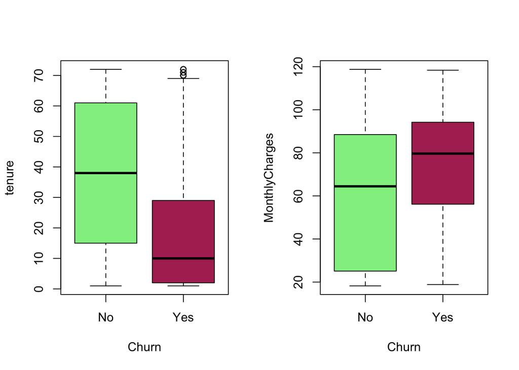

```r
par(mfrow=c(1,2))
boxplot(tenure~ Churn, data= data_cl, col= c("lightgreen", "maroon"))
boxplot(MonthlyCharges ~ Churn, data= data_cl, col= c("lightgreen", "maroon"))
```

Gdybyśmy chcieli podejrzeć outliery, przy okazji zauażamy, że są to osoby, które odeszły.

```r
library(dplyr)

data_cl %>%
  group_by(Churn)%>%
  mutate(
    Q1= quantile(tenure, 0.25),
    Q3= quantile(tenure, 0.75),
    rozstep= Q3-Q1,
    margin1 = Q1- 1.5*rozstep,
    margin2 = Q3 + 1.5*rozstep,
    outlier= tenure< margin1 | tenure > margin2
  )%>%
  filter(outlier)
```

```
## # A tibble: 23 × 27
## # Groups:   Churn [1]
##    customerID gender SeniorCitizen Partner Dependents tenure PhoneService
##    <fct>      <fct>          <int> <fct>   <fct>       <int> <fct>
##  1 4853-RULSV Male               0 No      No             70 Yes
##  2 2834-JRTUA Male               0 No      No             71 Yes
##  3 0201-OAMXR Female             0 No      No             70 Yes
##  4 4550-VBOFE Male               1 Yes     No             70 Yes
##  5 7317-GGVPB Male               0 Yes     No             71 Yes
##  6 8809-RIHDD Male               0 Yes     Yes            72 Yes
##  7 0917-EZOLA Male               1 Yes     No             72 Yes
##  8 0748-RDGGM Male               0 Yes     No             70 Yes
##  9 3886-CERTZ Female             0 Yes     No             72 Yes
## 10 6559-ILWKJ Male               0 Yes     No             71 No
## # ℹ 13 more rows
## # ℹ 20 more variables: MultipleLines <fct>, InternetService <fct>,
## #   OnlineSecurity <fct>, OnlineBackup <fct>, DeviceProtection <fct>,
## #   TechSupport <fct>, StreamingTV <fct>, StreamingMovies <fct>,
## #   Contract <fct>, PaperlessBilling <fct>, PaymentMethod <fct>,
## #   MonthlyCharges <dbl>, TotalCharges <dbl>, Churn <fct>, Q1 <dbl>, Q3 <dbl>,
## #   rozstep <dbl>, margin1 <dbl>, margin2 <dbl>, outlier <lgl>
```

Celowo pominęliśmy zmienną TotalCharges ponieważ jest ona liniowo zależna zarówno od zmiennej MonthlyCharges jak i Tenure, więc w modelu finalnym i tak nie będzie ona brana pod uwagę.

**Wniosek:** zarówno okres trwania umowy jak i miesięczne koszty mają realny i mocny wpływ na odejście lub nie klienta. Zauważamy, że potencjalnie “nowi” klienci, ze stażem krótszym niż 30 miesięcy mają tendencję do odejścia od firmy, więc to im trzeba poświęcić uwagę i zaproponować korzystniejsze warunki umowy, jednak zauważamy również poszczególne outliery pośród osób, które odeszły i są to osoby z bardzo długim stażem w firmie, więc jeśli chodzi o utratę klienta, również na nich należałoby zwrócić uwagę. Za pomocą kwartyli wytypowaliśmy te osoby. Są to dane bardziej w kontekście już realnego działania.

### Zmienne kategoryczne

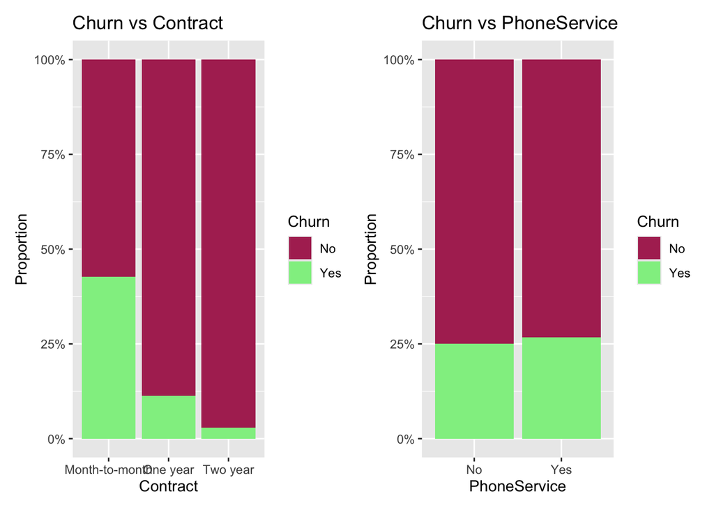

```r
library(patchwork)
library(ggplot2)

p1= ggplot(data_cl, aes(x= Contract, fill= Churn))+
  geom_bar(position=  "fill")+
  labs(
   y = "Proportion",
  title = "Churn vs Contract"
  ) +
  scale_y_continuous(labels = scales::percent)+
  scale_fill_manual(values= c("No"="maroon", "Yes"= "lightgreen"))

p2= ggplot(data_cl, aes(x= PhoneService, fill= Churn))+
  geom_bar(position=  "fill")+
  labs(
   y = "Proportion",
  title = "Churn vs PhoneService"
  ) +
  scale_y_continuous(labels = scales::percent)+
  scale_fill_manual(values= c("No"="maroon", "Yes"= "lightgreen"))

p1 + p2
```

**Wniosek:** umowy miesiąc-do-miesiąca są najbardziej ryzykowne dla firmy, gdyż najczęsciej odchodzą klienci, którzy mogą zerwać umowę w każdej chwili. Z kolei usługa telefoniczna praktycznie nie różni się w zależności od klasy.

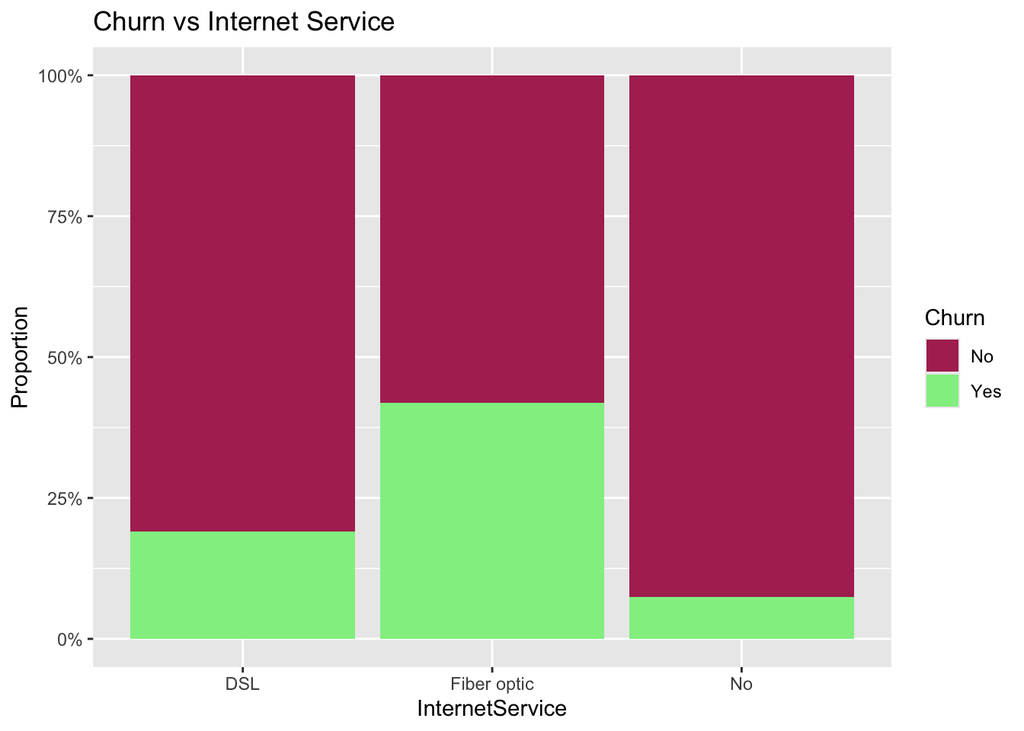

```r
ggplot(data_cl, aes(x = InternetService, fill = Churn)) +
  geom_bar(position = "fill") +
  labs(
    y = "Proportion",
    title = "Churn vs Internet Service"
  ) +
  scale_y_continuous(labels = scales::percent)+
  scale_fill_manual(values= c("No"="maroon", "Yes"= "lightgreen"))
```

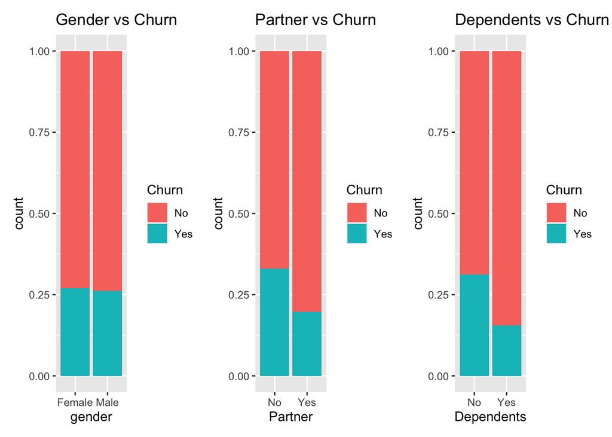

```r
p1 <- ggplot(data_cl, aes(x = gender, fill = Churn)) +
  geom_bar(position = "fill") +
  labs(title = "Gender vs Churn")

p2 <- ggplot(data_cl, aes(x = Partner, fill = Churn)) +
  geom_bar(position = "fill") +
  labs(title = "Partner vs Churn")

p3 <- ggplot(data_cl, aes(x = Dependents, fill = Churn)) +
  geom_bar(position = "fill") +
  labs(title = "Dependents vs Churn")

p1 + p2 + p3
```

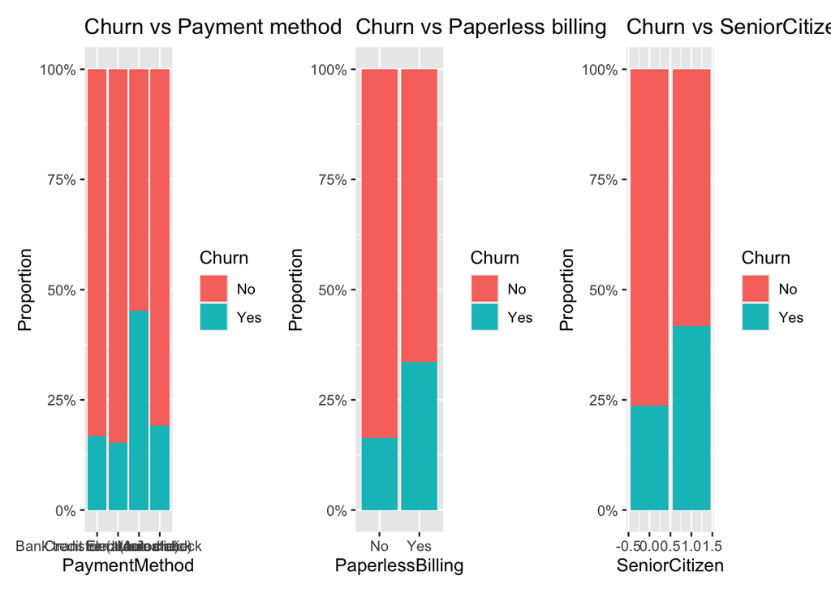

```r
p1= ggplot(data_cl, aes(x = PaymentMethod, fill = Churn)) +
  geom_bar(position = "fill") +
  labs(
    y = "Proportion",
    title = "Churn vs Payment method"
  ) +
  scale_y_continuous(labels = scales::percent)

p2= ggplot(data_cl, aes(x = PaperlessBilling, fill = Churn)) +
  geom_bar(position = "fill") +
  labs(
    y = "Proportion",
    title = "Churn vs Paperless billing"
  ) +
  scale_y_continuous(labels = scales::percent)
p3= ggplot(data_cl, aes(x = SeniorCitizen, fill = Churn)) +
  geom_bar(position = "fill") +
  labs(
    y = "Proportion",
    title = "Churn vs SeniorCitizen"
  ) +
  scale_y_continuous(labels = scales::percent)

p1+p2+p3
```

## Podsumowanie

Istotne różnice między klasami zauważyliśmy dla wszystkich zmiennych poza PhoneServic i gender. Pominiemy te zmienne oraz CustomerID i TotalCharges w konstruowaniu modelu i sprawdzimy, jak nasz model zadziała.

## Korelacja

### Zmienne ilościowe

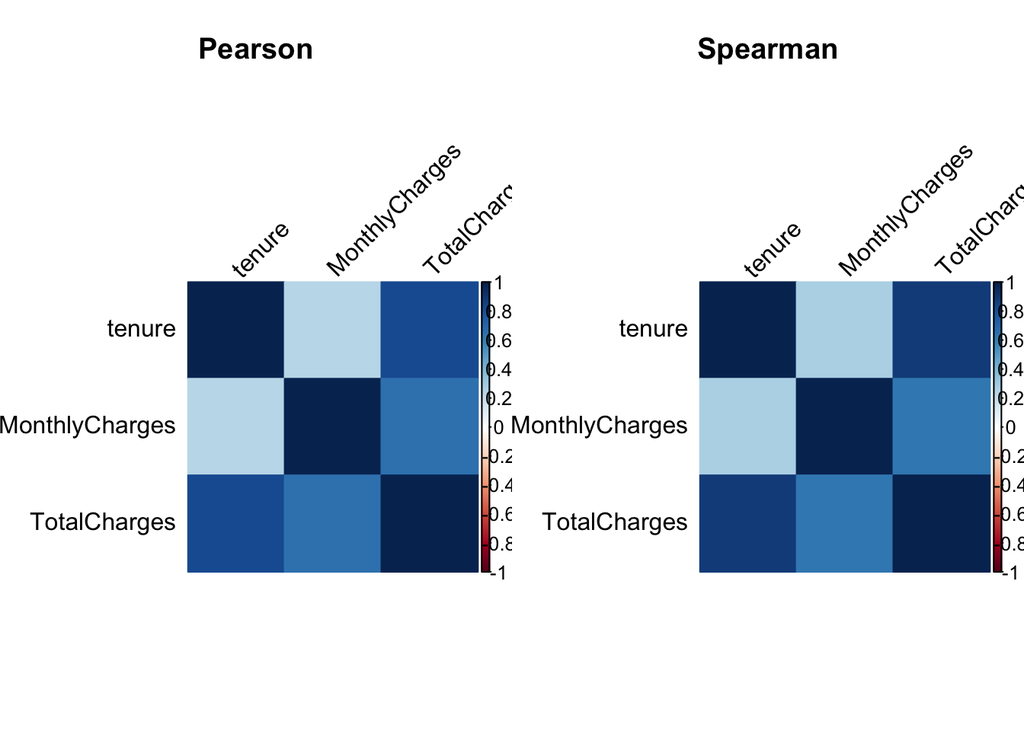

```r
library(corrplot)
num_data= data_cl[,c("tenure", "MonthlyCharges", "TotalCharges")]
cor1= cor(num_data, method="pearson")
cor2= cor(num_data, method= "spearman")
layout(matrix(1:2, nrow=1))
par(mar=c(1,1,3,1))

corrplot(cor1, method="color", type="full", tl.col="black", tl.srt=45)
title(main="Pearson", line=1)

corrplot(cor2, method="color", type="full", tl.col="black", tl.srt=45)
title(main="Spearman", line=1)
```

**Wniosek:** jak już wcześniej wspomnieliśmy, ewidentnie zauważamy silną korelację między Tenure a TotalCharges oraz MonthlyCharges i TotalCharges. Zależność mocno oczywista, przez co pozbędziemy się zmiennej TotalCharges. Przy Tenure i MonthlyCharges ta korelacja nie jest aż tak groźna, a obie zmienne istotnie wpływają na Churn.

### Zmienne kategoryczne

Zależność pomiędzy zmiennymi InternetService oraz zmiennymi opisującymi dodatkowe usługi internetowe wynika ze struktury danych. W przypadku braku usługi InternetService (InternetService = “No”), wszystkie zmienne dotyczące usług internetowych przyjmują wartość „No internet service”, co oznacza, że ich wartości są warunkowo determinowane przez jedną zmienną. W związku z tym zmienne te nie są niezależne informacyjnie.

Początkowym zamysłem było stworzenie modelu z dostępnych danych w całości, jednak silna zależność między kolumnami powodowała błąd w trakcie tworzenia modelu, gdyż macierz kowariancji zmiennych predykcyjnych była nieodwracalna. DLatego wykonany został taki krok:

```r
internet_vars <- c("OnlineSecurity", "OnlineBackup", "DeviceProtection",
                   "TechSupport", "StreamingTV", "StreamingMovies")

for (v in internet_vars) {
  data_cl[[v]] <- factor(ifelse(data_cl[[v]] == "No internet service", "No", as.character(data_cl[[v]])))
}
```

```r
data_cl$MultipleLines <- factor(ifelse(data_cl$MultipleLines == "No phone service", "No", as.character(data_cl$MultipleLines)))
```

Niestety, chociaż pozbyliśmy się problemu z singularnością macierzy kowariancji, problem ze strukturalną zaleznością nadal pozostał, tzn nadal zmienna InternetService determinuje zmienne OnlineSecurity, OnlineBackup, itd. To pozwala nam wnioskować, iż nawet jeśli model nie wyrzuci błędu “correlation”, to estymowana macież kowariancji może być niestabilna i może nie odzwierciedlać “prawdy”. Uwzględnimy to przy budowie modelu.

Strukturalna zależność widoczna jest również w relacjach PhoneService-MultipleLines oraz PaperlessBilling i PaymentMethod.

## Wnioski do budowy modeli

Na podstawie przeprowadzonej analizy eksploracyjnej danych (EDA) sformułowano następujące wnioski istotne dla budowy modeli klasyfikacyjnych LDA oraz QDA:

**1. Zależność zmiennych liczbowych**

Zaobserwowano silną korelację pomiędzy zmiennymi TotalCharges, MonthlyCharges oraz tenure. W szczególności zmienna TotalCharges jest silnie zależna od tenure i MonthlyCharges, W związku z tym została ona usunięta z dalszej analizy, aby uniknąć problemów związanych z nadmiarową informacją oraz niestabilnością estymacji macierzy kowariancji.

**2. Strukturalna zależność zmiennych kategorycznych**

W zbiorze danych występuje strukturalna zależność pomiędzy zmienną InternetService a zmiennymi opisującymi dodatkowe usługi internetowe (OnlineSecurity, OnlineBackup, DeviceProtection, TechSupport, StreamingTV, StreamingMovies). W przypadku braku usługi internetowej wszystkie powyższe zmienne przyjmują wartość „No internet service”, co oznacza, że ich wartości są warunkowo determinowane przez jedną zmienną. W konsekwencji zmienne te nie wnoszą w pełni niezależnej informacji i mogą powodować problemy z degeneracją macierzy kowariancji. Podobny problem zauważamy w relacjach PaperlessBilling~ PaymentMethod oraz PhoneService~ MultipleLines. Zatem uwzględnimy model uproszczony, opierający się na PaymentMethod oraz InternetService, gdyż nie wykryliśmy znaczącego wpływu PhoneService, czy MultipleLines na Churn.

# Budowa modeli

Najpierw zbudujemy model pełny, jedynie pozbywajac się customerID oraz TotalCharges, a później zrealizujemy nasz plan oparty na surowszej redukcji cech.

## LDA model

Liniowa analiza dyskryminacyjna (LDA) to metoda oparta na estymacji rozkładu zmiennej objaśnianej (i przypisaniu obswrwacji do kategorii o największym prawdopodobieństwie warunkowym), która szuka **liniowej** granicy decyzyjnej. Zakłada ona, że obserwacje są niezależne, w każdej klasie dane mają rozkład normalny, a macierz kowariancji jest wspólna dla tych samych klas.

```r
library(MASS)
library(caret)

data_cl_lightreduced <- data_cl %>%
  dplyr::select(-customerID, -TotalCharges)

set.seed(123)
train_index <- createDataPartition(data_cl$Churn, p = 0.8, list = FALSE)
```

```r
lda_general_model= lda(Churn~ ., data= data_cl_lightreduced[train_index,])
lda_general_pred= predict(lda_general_model, data_cl_lightreduced[-train_index,])
```

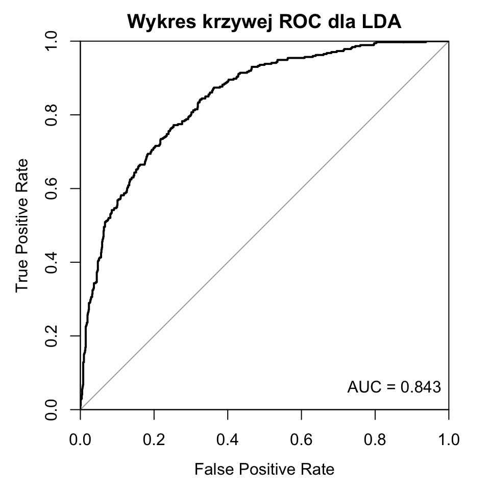

```r
library(pROC)

prob_positive <- lda_general_pred$posterior[, "Yes"]

roc_obj <- roc(data_cl_lightreduced[-train_index,]$Churn, prob_positive,
               levels = c("No", "Yes"))
plot(roc_obj,
     legacy.axes = TRUE,
     xaxs = "i",
     yaxs = "i",
     xlab = "False Positive Rate",
     ylab = "True Positive Rate",
     main= "Wykres krzywej ROC dla LDA")
legend("bottomright", legend = paste("AUC =", round(auc(roc_obj), 3)), bty = "n")
```

## LDA reduced model

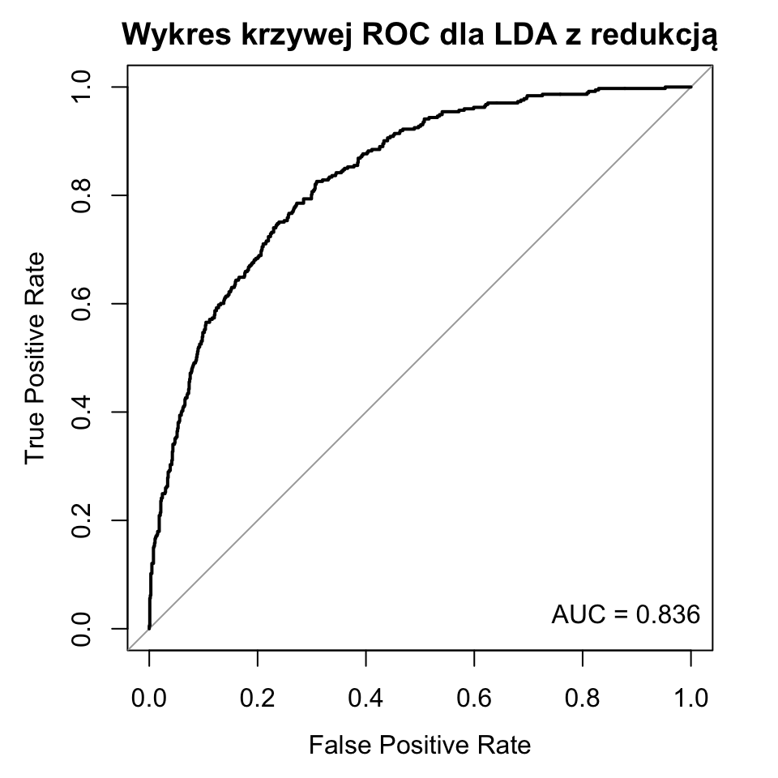

```r
data_cl_fullyreduced <- data_cl %>%
  dplyr::select(
    -customerID,
    -TotalCharges,
    -PhoneService,
    -MultipleLines,
    -gender,
    -OnlineSecurity,
    -OnlineBackup,
    -TechSupport,
    -DeviceProtection,
    -StreamingTV,
    -StreamingMovies
  )

lda_reduced_model <- lda(Churn ~ ., data = data_cl_fullyreduced[train_index, ])

lda_reduced_pred <- predict(lda_reduced_model, data_cl_fullyreduced[-train_index, ])

prob_positive1 <- lda_reduced_pred$posterior[, "Yes"]

roc_obj1 <- roc(data_cl_fullyreduced[-train_index, ]$Churn,
                 prob_positive1,
                 levels = c("No", "Yes"))

plot(roc_obj1,
     legacy.axes = TRUE,
     xlab = "False Positive Rate",
     ylab = "True Positive Rate",
     main = "Wykres krzywej ROC dla LDA z redukcją")

legend("bottomright",
       legend = paste("AUC =", round(auc(roc_obj1), 3)),
       bty = "n")
```

## QDA full model

Kwadratowa analiza dyskryminacyjna (QDA) jest również metodą opartą na estymacji rozkładu zmiennej Churn, natomiast najistotniejszą różnicą jest to, że nie wymagamy już liniowej granicy decyzyjnej. Daje to większe pole manewru, ale również zwiększa ryzyko overfittingu. Tutaj również zakładamy niezależność i rozkład normalny, ale dopuszczamy, by macierze kowariancji mogły być różne. QDA jest rekomendowane przy większych zbiorach danych.

Zbudujmy teraz również model QDA.

```r
qda_general_model <- qda(Churn ~ ., data = data_cl_lightreduced[train_index, ])

qda_general_pred <- predict(qda_general_model, data_cl_lightreduced[-train_index, ])
```

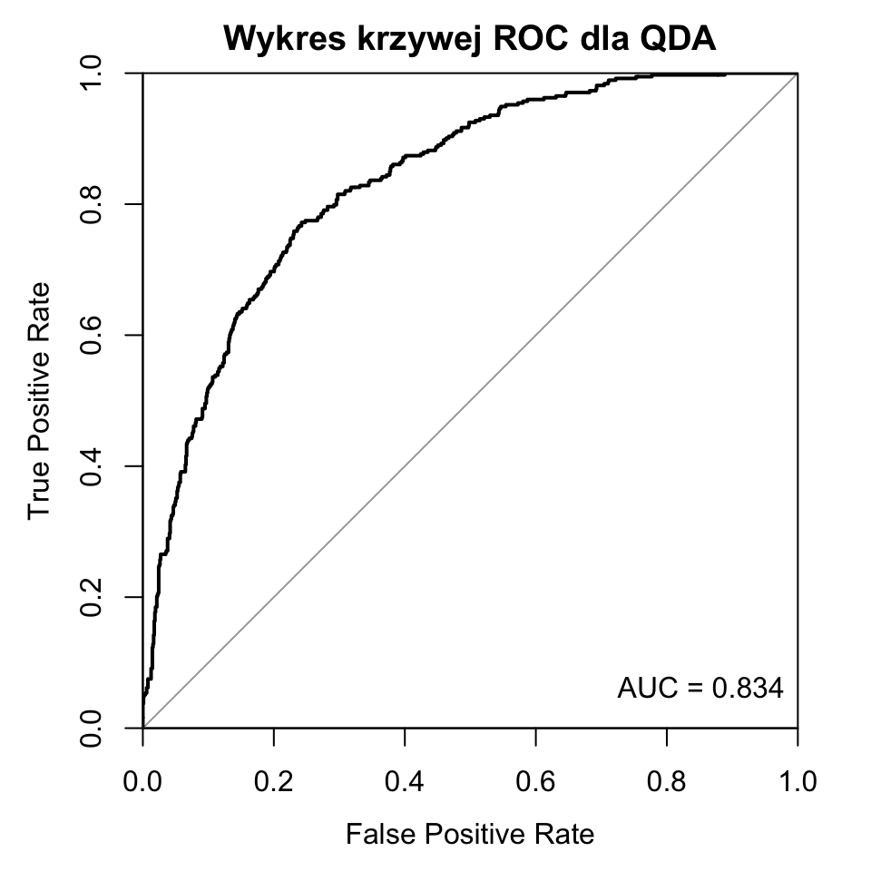

```r
prob_positive2 <- qda_general_pred$posterior[, "Yes"]

roc_obj2 <- roc(
  response = data_cl_lightreduced[-train_index, ]$Churn,
  predictor = prob_positive2,
  levels = c("No", "Yes")
)

plot(roc_obj2,
     legacy.axes = TRUE,
     xaxs = "i",
     yaxs = "i",
     xlab = "False Positive Rate",
     ylab = "True Positive Rate",
     main = "Wykres krzywej ROC dla QDA")

legend("bottomright",
       legend = paste("AUC =", round(auc(roc_obj2), 3)),
       bty = "n")
```

## QDA reduced model

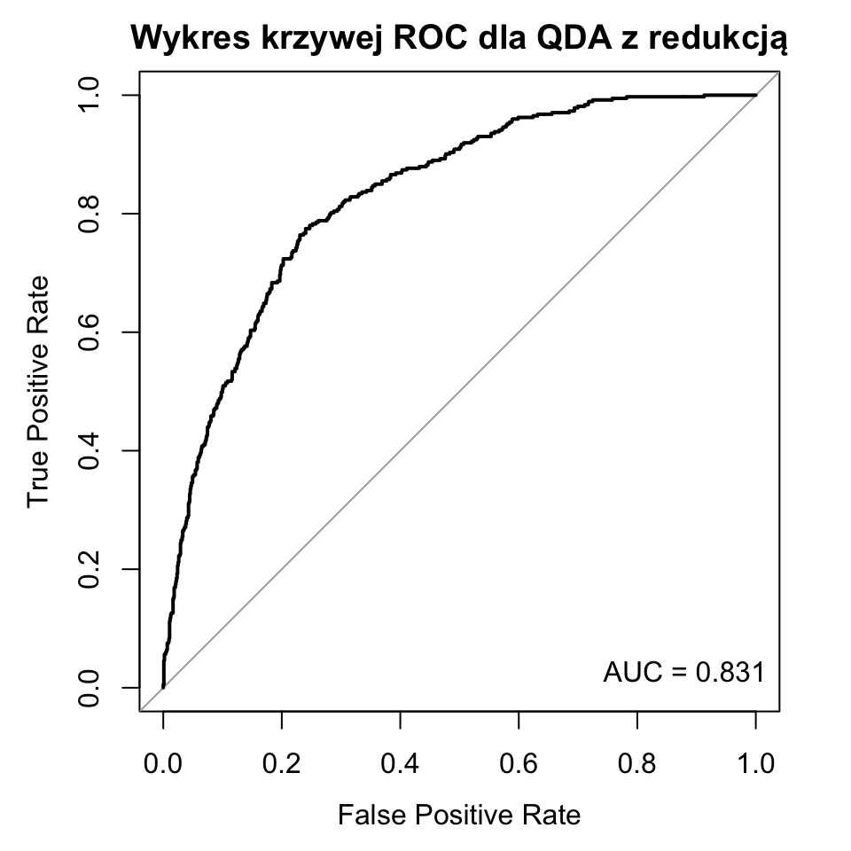

```r
qda_reduced_model <- qda(Churn ~ ., data = data_cl_fullyreduced[train_index, ])

qda_reduced_pred <- predict(qda_reduced_model, data_cl_fullyreduced[-train_index, ])

prob_positive3 <- qda_reduced_pred$posterior[, "Yes"]

roc_obj3 <- roc(data_cl_fullyreduced[-train_index, ]$Churn,
                 prob_positive3,
                 levels = c("No", "Yes"))

plot(roc_obj3,
     legacy.axes = TRUE,
     xlab = "False Positive Rate",
     ylab = "True Positive Rate",
     main = "Wykres krzywej ROC dla QDA z redukcją")

legend("bottomright",
       legend = paste("AUC =", round(auc(roc_obj3), 3)),
       bty = "n")
```

## Wstępne wnioski

Okazuje się, iż redukcja cech wcale nie wyszła na dobre, gdyż pozbywając sie potencjalnie strukturalnie zależnych danych, pozbyliśmy się również “impulsów”, które decydowały o tym czy klient odszedł, czy nie, zatem pozostajemy przy pełnym modelu, jedynie bez CustomerID i TotalCharges.

# Ocena modeli

## Porównanie modeli LDA i QDA full

Zanim przejdziemy do analizy modeli i oceny błędów, zastanówmy się - który błąd jest dla nas gorszy? Jest to oczywiście uznaniowe, natomiast według nas większe szkody spowoduje strata klienta, którego błędnie zaklasyfikowaliśmy jako kogoś, kto nie opuści naszej firmy (i nie powalczyliśmy o jego zatrzymanie) niż sytuacja przeciwna, w której klient, który nie zamierzał rezygnować z naszych usług, otrzymuje jakieś formy zachęty do pozostania, może nawet promocje (a więc straty finansowe dla nas).

Staramy się zatem unikać błędów FN (fałszywie negatywnych), nawet kosztem większej liczby błędów FP (fałszywie pozytywnych). Ponadto, jak już wspominaliśmy powyżej, dysproporcja klas w zmiennej objaśnianej sprawia, że nie możemy polegać na metryce Accuracy i musimy szukać innych rozwiązań.

## Macierz błędów

Macierz błędów (confusion matrix) to jeden z najbardziej powszechnych i najwięcej pokazujących sposobów wizualizacji błędów popełnianych przez model, z wyszczególnieniem tego, jaki to błąd, co będzie dla nas bardzo ważne. Obliczenia tych błędów będą podstawą do wyliczeń kolejnych metryk.

Rozpiszmy te macierze dla obu modeli, począwszy od LDA.

### Macierz błędów dla LDA

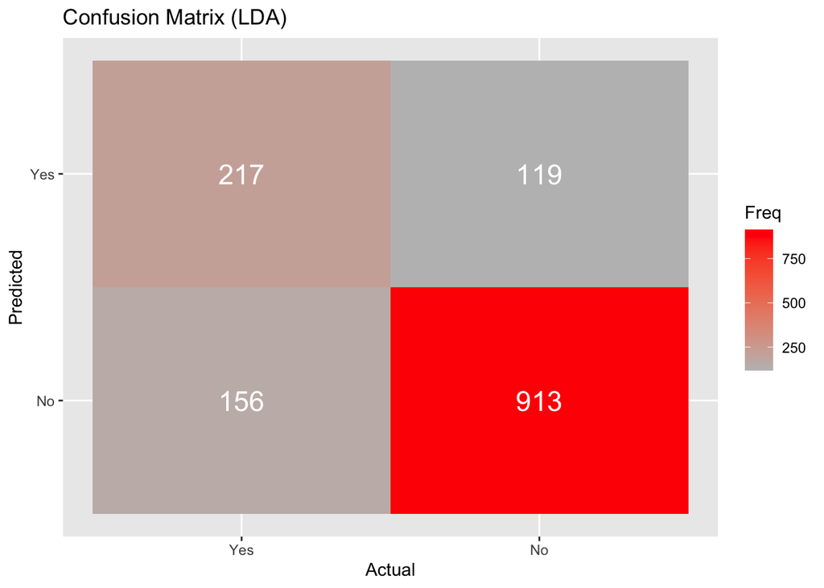

```r
train_data=data_cl_lightreduced[train_index,]
test_data=data_cl_lightreduced[-train_index,]
test_data$Churn <- factor(test_data$Churn, levels = c("Yes", "No"))

lda_class <- factor(lda_general_pred$class, levels = c("No", "Yes"))
table_lda <- table(
  Predicted = lda_class,
  Actual = test_data$Churn
)
cm_df <- as.data.frame(table_lda)


ggplot(cm_df, aes(x = Actual, y = Predicted, fill = Freq)) +
  geom_tile() +
  geom_text(aes(label = Freq), color = "white", size = 6) +
  scale_fill_gradient(low = "grey", high = "red") +
  labs(title = "Confusion Matrix (LDA)",
       x = "Actual",
       y = "Predicted")
```

Spójrzmy następnie na macierz błędów dla modelu QDA.

### Macierz błędów dla QDA

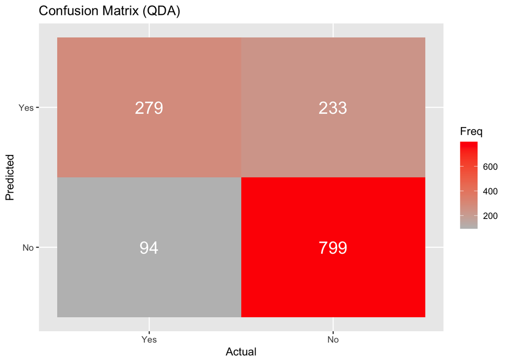

```r
qda_class <- factor(qda_general_pred$class, levels = c("No", "Yes"))
table_qda <- table(
  Predicted = qda_class,
  Actual = test_data$Churn
)
cm_df_qda<- as.data.frame(table_qda)


ggplot(cm_df_qda, aes(x = Actual, y = Predicted, fill = Freq)) +
  geom_tile() +
  geom_text(aes(label = Freq), color = "white", size = 6) +
  scale_fill_gradient(low = "grey", high = "red") +
  labs(title = "Confusion Matrix (QDA)",
       x = "Actual",
       y = "Predicted")
```

Mając w głowie nasze kryterium (preferencja FP kosztem FN) oceniamy, że lepszy jest model QDA. Co prawda ma on trochę gorszą accuracy (więcej razy się myli, $275$ vs $327$), natomiast jedynie $29 \%$ błędów to błędy fałszywie negatywne. W modelu LDA stanowią one aż prawie $57\%$ wszystkich błędów.

## F1 Score oraz Recall

Recall, czyli czułość modelu, opisuje jaka część wszystkich rzeczywistych pozytywnych obserwacji została poprawnie sklasyfikowana. Zależy nam więc na tym, by był jak największy (nawet kosztem niższej precyzji, jak pisaliśmy już powyżej). F1 natomiast to średnia harmoniczna obu tych metryk, pewnego rodzaju kompromis między nimi.

Obliczmy teraz wartości wspomnianych metryk dla modeli LDA oraz QDA.

LDA:

```r
TP_lda = table_lda["Yes", "Yes"]
FP_lda = table_lda["Yes", "No"]
FN_lda = table_lda["No", "Yes"]

precision_lda = TP_lda/(TP_lda+FP_lda)
recall_lda = TP_lda/(TP_lda+FN_lda)
f1_lda = 2 * precision_lda * recall_lda / (precision_lda + recall_lda)

f1_lda
```

```
## [1] 0.6121298
```

```r
recall_lda
```

```
## [1] 0.5817694
```

QDA:

```r
TP_qda = table_qda["Yes", "Yes"]
FP_qda = table_qda["Yes", "No"]
FN_qda = table_qda["No", "Yes"]

precision_qda = TP_qda/(TP_qda+FP_qda)
recall_qda = TP_qda/(TP_qda+FN_qda)
f1_qda = 2 * precision_qda * recall_qda / (precision_qda + recall_qda)

f1_qda
```

```
## [1] 0.6305085
```

```r
recall_qda
```

```
## [1] 0.7479893
```

O ile w przypadku metryki F1 różnica jest nieznaczna, o tyle w przypadku Recallu widać, że model QDA ma o wiele większą wartość, co zresztą zaobserwowaliśmy przy okazji macierzy błędów. Potwierdza to oczywiście to, co wcześniej podkreśliliśmy - model QDA wydaje się lepszy.

## Sprawdzenie overfittingu

```r
qda_train_prob <- predict(qda_general_model)$posterior[, "Yes"]
qda_test_prob  <- qda_general_pred$posterior[, "Yes"]

roc_train <- roc(train_data$Churn, qda_train_prob, levels=c("No","Yes"))
roc_test  <- roc(test_data$Churn, qda_test_prob, levels=c("No","Yes"))

auc(roc_train)
```

```
## Area under the curve: 0.844
```

```r
auc(roc_test)
```

```
## Area under the curve: 0.8336
```

Wartość AUC wyniosła 0.844 na zbiorze treningowym oraz 0.8336 na zbiorze testowym. Niewielka różnica pomiędzy wynikami wskazuje, że model QDA nie wykazuje oznak overfittingu i zachowuje dobrą zdolność generalizacji na nowych danych. Otrzymane wartości AUC świadczą o dobrej jakości klasyfikacji oraz zdolności modelu do rozróżniania klientów rezygnujących i pozostających w usłudze.

## Podsumowanie efektów do tej pory

1.Celem analizy było zbudowanie modeli klasyfikacyjnych (LDA i QDA) do predykcji rezygnacji klientów (Churn).

2.Przeprowadzono eksploracyjną analizę danych (EDA), identyfikując strukturę zmiennych oraz nierównowagę klas.

3.Usunięto zmienne o ograniczonej użyteczności lub potencjalnie redundatne (m.in. TotalCharges, CustomerID).

4.Zbudowano modele LDA i QDA w wersji pełnej oraz zredukowanej.

5.Ocenę modeli przeprowadzono na podstawie krzywej ROC, AUC oraz macierzy pomyłek.

6.Ze względu na charakter problemu szczególną wagę przypisano błędom FN (fałszywie negatywnym).

7.Model QDA uzyskał wyższy recall, co oznacza lepsze wykrywanie klientów zagrożonych odejściem.

8.Na tej podstawie wybrano model QDA jako model końcowy, jako bardziej zgodny z celem biznesowym.